# Exam 2

Krista Noe

3/22/2021

1. Import this dataset into R and inspect the first several rows of your data

```r
data = read.csv("Exam 2 Data.csv")
head(data)
```

```
##    y          x1          x2 x3
## 1  2  1.37034210 -0.66615843  b
## 2  2 -0.70417232 -0.03705622  c
## 3  4 -0.04223752 -1.53148692  c
## 4  9 -0.56711072 -0.06529335  b
## 5  1  0.31189773  0.81650472  a
## 6 13 -0.35994479 -0.80042308  b
```

2. Fit a Poisson model that assumes your response is a function of x1, x2, and x3. Include an interaction between x1 and x2 only (i.e., do not include an interaction between your categorical variables and any other variables).

```r
fit <- glm(y ~ x1*x2 + x3, family = poisson, data = data)
summary(fit)
```

```
##
## Call:
## glm(formula = y ~ x1 * x2 + x3, family = poisson, data = data)
##
## Deviance Residuals:
##     Min       1Q   Median       3Q      Max
## -2.3620  -0.6973  -0.1007   0.5236   2.6779
##
## Coefficients:
##             Estimate Std. Error z value Pr(>|z|)
## (Intercept)  1.13258    0.08540  13.262  < 2e-16 ***
## x1          -1.03491    0.05019 -20.620  < 2e-16 ***
## x2          -0.90839    0.06977 -13.021  < 2e-16 ***
## x3b          0.37532    0.09246   4.059 4.92e-05 ***
## x3c         -0.88354    0.12072  -7.319 2.50e-13 ***
## x1:x2       -0.28868    0.05142  -5.614 1.98e-08 ***
## ---
## Signif. codes:  0 '***' 0.001 '**' 0.01 '*' 0.05 '.' 0.1 ' ' 1
##
## (Dispersion parameter for poisson family taken to be 1)
##
##     Null deviance: 720.551  on 99  degrees of freedom
## Residual deviance:  89.088  on 94  degrees of freedom
## AIC: 392.86
##
## Number of Fisher Scoring iterations: 5
```

3. Interpret the effect of variable x1 when x2 = -1

This is the equation:

$$y = \beta_0 \ + \beta_1X_1 \ + \beta_2X2 \ + \beta_3b \ + \beta_4c \ + \beta_5X1X2$$

Rearrange to find effective slope:

$$y = \beta_0 \ + X1*(\beta_1 \ + \beta_5X2) \ + \beta_2X2 + \beta_3b \ + \beta_4c$$

```r
# beta 1 + beta 5*-1 = answer

betas <- coef(fit)
betas[2] + betas[6]*-1
```

```
##         x1
## -0.7462245
```

Beta 1 + Beta 5*X2 represents the change in log odds associated with a 1 unit change in X1. In this data, log odds success decreases by 0.74 for every 1 unit change in X1

4. Plot expected counts ±90% confidence intervals over the observed range of variable x1. Assume variable when **x2 = -1** and category **“a”**.

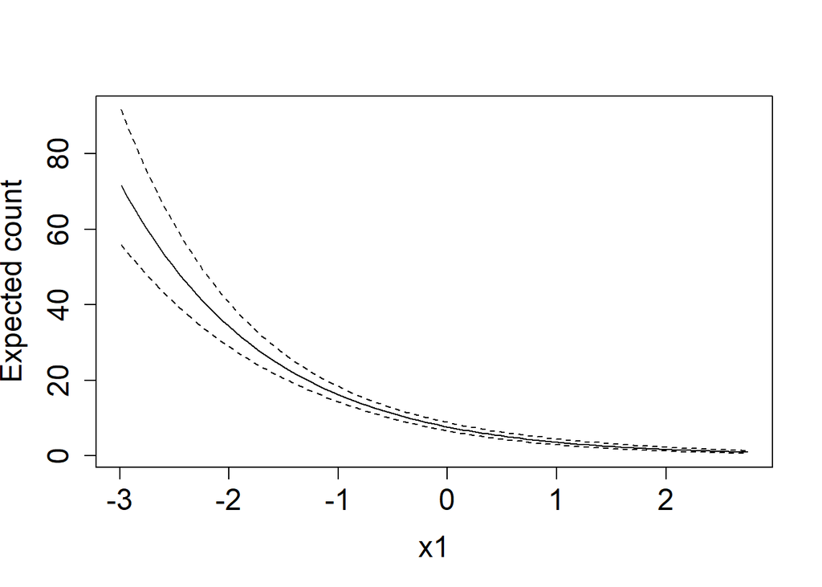

```r
nd <- data.frame(
  x1 = seq(min(data$x1), max(data$x1), length.out = 100),
  x2 = -1,
  x3 = factor('a', levels = c('a', 'b', 'c'))
)


prd <- predict.glm(object = fit, newdata = nd, type = 'link', se.fit = T) #expected count
# 90% confidence intervals
low <- exp(prd$fit - qnorm(0.95) * prd$se.fit)
high <- exp(prd$fit + qnorm(0.95) * prd$se.fit)


plot(y = exp(prd$fit), x = nd$x1, xlab = 'x1',
  ylab = 'Expected count', cex.axis = 1.5, cex.lab = 1.5,
  ylim = c(min(low), max(high)), type = 'l')
lines(x = nd$x1, y = low, lty = 2)
lines(x = nd$x1, y = high, lty = 2)
```

5. Interpret the effect of variable x3.

```r
summary(fit)
```

```
##
## Call:
## glm(formula = y ~ x1 * x2 + x3, family = poisson, data = data)
##
## Deviance Residuals:
##     Min       1Q   Median       3Q      Max
## -2.3620  -0.6973  -0.1007   0.5236   2.6779
##
## Coefficients:
##             Estimate Std. Error z value Pr(>|z|)
## (Intercept)  1.13258    0.08540  13.262  < 2e-16 ***
## x1          -1.03491    0.05019 -20.620  < 2e-16 ***
## x2          -0.90839    0.06977 -13.021  < 2e-16 ***
## x3b          0.37532    0.09246   4.059 4.92e-05 ***
## x3c         -0.88354    0.12072  -7.319 2.50e-13 ***
## x1:x2       -0.28868    0.05142  -5.614 1.98e-08 ***
## ---
## Signif. codes:  0 '***' 0.001 '**' 0.01 '*' 0.05 '.' 0.1 ' ' 1
##
## (Dispersion parameter for poisson family taken to be 1)
##
##     Null deviance: 720.551  on 99  degrees of freedom
## Residual deviance:  89.088  on 94  degrees of freedom
## AIC: 392.86
##
## Number of Fisher Scoring iterations: 5
```

```r
# 0.375 (b)
# -0.883 (c)
```

Between categories a and b, the difference in log odds is 0.375.  
Between categories a and c, the difference in log odds is -0.883.

6. Use contrasts to evaluate the null hypothesis that the difference in log expected count between levels “b” and “c” = 0. Fix x1 and x2 at their means.

```r
x <- matrix(c(0, 0, 0, -1, 1, 0), nrow = 1)

library(multcomp)
contrast <- glht(model = fit, linfct = x)
summary(contrast)
```

```
##
##   Simultaneous Tests for General Linear Hypotheses
##
## Fit: glm(formula = y ~ x1 * x2 + x3, family = poisson, data = data)
##
## Linear Hypotheses:
##        Estimate Std. Error z value Pr(>|z|)
## 1 == 0  -1.2589     0.1197  -10.52   <2e-16 ***
## ---
## Signif. codes:  0 '***' 0.001 '**' 0.01 '*' 0.05 '.' 0.1 ' ' 1
## (Adjusted p values reported -- single-step method)
```

```r
#check by x3c - x3b
betas[5] - betas[4]
```

```
##       x3c
## -1.258863
```

Our null hypothesis is the difference between levels b and c of variable x3 is = 0. Because of a low p-value (<2e-16), we reject our null; therefore, the difference between factor levels b and c **is** different from 0.

7. Derive the test statistic and p-value associated with the interaction between x1 and x2. What is the null hypothesis? Do we reject or fail to reject this null hypothesis? Defend your answer.

```r
# wald for test statistic
ts <- betas[6] / summary(fit)[['coefficients']]['x1:x2', 'Std. Error']

# p-value
2 * pnorm(-1 * abs(ts), mean = 0, sd = 1)
```

```
##        x1:x2
## 1.976182e-08
```

```r
# checks out with summary output as well
summary(fit)[['coefficients']]['x1:x2', 'Pr(>|z|)']
```

```
## [1] 1.976182e-08
```

The null hypothesis is that this interaction term x1:x2 (beta 5) = 0. Because beta 5 is the change in the effective slope coefficient of x1 associated with a 1-unit change in x2, and given our low p-value of 1.976182e-08, we must reject our null and can conclude that there is sufficient evidence that the effect of variable x1 depends on the level of x2.

## Other Questions

8. assume you have the following realizations of random variable Y : y = (1, 0) Further assume realizations of the random variable Y are Bernoulli distributed: y ∼ Bernoulli(p). What is the probability of observing each of these random variables assuming the log odds of success = -2?

```r
dbinom(c(1, 0), size = 1, prob = plogis(-2))
```

```
## [1] 0.1192029 0.8807971
```

9. What is the “support” of a Bernoulli random variable? What are the acceptable values of it’s sole parameter? To which quantity do we apply a link function, and why do we do this? What is the principle link function we use in binomial (i.e., logistic) regression, and what it it’s inverse function?

Bernoulli random variables are either 0 or 1. It’s sole parameter is p which represents the probability of success in each trial. Acceptable values for p are (0,1). We apply the link function to the parameter p. We do this because it maps a number bounded between 0 and 1 to the real number line. We usually use a logit link function. It’s inverse function is exp(x)/1+exp(x) = p.

10. What is a fundamental assumption we make to derive inference when comparing two levels of a categorical random variable?

When using categorical variables, the coefficient is the difference in the response between the reference and the level of the categorical covariate (ex. level ‘b’ or ‘c’).